# UE20CS935- INTRODUCTION TO DEEP LEARNING & ITS APPLICATIONS

## Model Questions - Set 2

**Dataset used: Unet_Dataset**

### SECTION – C (20 Marks)

```
5. Develop a Semantic segmentation model using Unet architecture on the given dataset.
Dataset contains the images and the corresponding masks. Find the dataset under the folder “Unet_Dataset”.

Note that the masks are binary. Define the architecture accordingly.
Run the model for minimum 5 epochs and present your result. The solution will be evaluated based on approach only as it take lot of epochs to produce good result.
```

### Step 1: Load the Dataset

```python
import os
import numpy as np
import cv2
```

```python
# Paths to the dataset
image_dir = "C:/Users/DELL/Desktop/Unet_Dataset/images"
mask_dir = "C:/Users/DELL/Desktop/Unet_Dataset/MASKS_BW"
```

```python
# Initialize arrays
images = []
masks = []

# Load images
for img_name in sorted(os.listdir(image_dir)):
    img_path = os.path.join(image_dir, img_name)
    img = cv2.imread(img_path)
    img = cv2.resize(img, (128, 128))
    images.append(img)

# Load masks
for mask_name in sorted(os.listdir(mask_dir)):
    mask_path = os.path.join(mask_dir, mask_name)
    mask = cv2.imread(mask_path, cv2.IMREAD_GRAYSCALE)
    mask = cv2.resize(mask, (128, 128))
    masks.append(mask)

# Convert lists to numpy arrays
images = np.array(images)
masks = np.array(masks)

# Reshape masks to add channel dimension
masks = np.expand_dims(masks, axis=-1)

print(f'Images shape: {images.shape}')
print(f'Masks shape: {masks.shape}')
```

```
Images shape: (150, 128, 128, 3)
Masks shape: (150, 128, 128, 1)
```

### Step 2: Scale the Arrays

```python
images = images / 255.0
masks = masks / 255.0
```

### Step 3: Split the Data into Train and Test Sets

```python
from sklearn.model_selection import train_test_split

X_train, X_test, y_train, y_test = train_test_split(images, masks, test_size=0.2, random_state=42)

print(f'Training set shape: {X_train.shape}, {y_train.shape}')
print(f'Test set shape: {X_test.shape}, {y_test.shape}')
```

```
Training set shape: (120, 128, 128, 3), (120, 128, 128, 1)
Test set shape: (30, 128, 128, 3), (30, 128, 128, 1)
```

### Step 4: Define the U-Net Model

```python
import tensorflow as tf
from tensorflow.keras import layers, models

def unet_model(input_size=(128, 128, 3)):
    inputs = layers.Input(input_size)

    # Encoder
    c1 = layers.Conv2D(64, (3, 3), activation='relu', padding='same')(inputs)
    c1 = layers.Conv2D(64, (3, 3), activation='relu', padding='same')(c1)
    p1 = layers.MaxPooling2D((2, 2))(c1)

    c2 = layers.Conv2D(128, (3, 3), activation='relu', padding='same')(p1)
    c2 = layers.Conv2D(128, (3, 3), activation='relu', padding='same')(c2)
    p2 = layers.MaxPooling2D((2, 2))(c2)

    c3 = layers.Conv2D(256, (3, 3), activation='relu', padding='same')(p2)
    c3 = layers.Conv2D(256, (3, 3), activation='relu', padding='same')(c3)
    p3 = layers.MaxPooling2D((2, 2))(c3)

    c4 = layers.Conv2D(512, (3, 3), activation='relu', padding='same')(p3)
    c4 = layers.Conv2D(512, (3, 3), activation='relu', padding='same')(c4)
    p4 = layers.MaxPooling2D((2, 2))(c4)

    # Bottleneck
    c5 = layers.Conv2D(1024, (3, 3), activation='relu', padding='same')(p4)
    c5 = layers.Conv2D(1024, (3, 3), activation='relu', padding='same')(c5)

    # Decoder
    u6 = layers.Conv2DTranspose(512, (2, 2), strides=(2, 2), padding='same')(c5)
    u6 = layers.concatenate([u6, c4])
    c6 = layers.Conv2D(512, (3, 3), activation='relu', padding='same')(u6)
    c6 = layers.Conv2D(512, (3, 3), activation='relu', padding='same')(c6)

    u7 = layers.Conv2DTranspose(256, (2, 2), strides=(2, 2), padding='same')(c6)
    u7 = layers.concatenate([u7, c3])
    c7 = layers.Conv2D(256, (3, 3), activation='relu', padding='same')(u7)
    c7 = layers.Conv2D(256, (3, 3), activation='relu', padding='same')(c7)

    u8 = layers.Conv2DTranspose(128, (2, 2), strides=(2, 2), padding='same')(c7)
    u8 = layers.concatenate([u8, c2])
    c8 = layers.Conv2D(128, (3, 3), activation='relu', padding='same')(u8)
    c8 = layers.Conv2D(128, (3, 3), activation='relu', padding='same')(c8)

    u9 = layers.Conv2DTranspose(64, (2, 2), strides=(2, 2), padding='same')(c8)
    u9 = layers.concatenate([u9, c1])
    c9 = layers.Conv2D(64, (3, 3), activation='relu', padding='same')(u9)
    c9 = layers.Conv2D(64, (3, 3), activation='relu', padding='same')(c9)

    outputs = layers.Conv2D(1, (1, 1), activation='sigmoid')(c9)

    model = models.Model(inputs=[inputs], outputs=[outputs])
    return model

model = unet_model()
model.compile(optimizer='adam', loss='binary_crossentropy', metrics=['accuracy'])
model.summary()
```

```
Model: "functional"
```

```
┏━━━━━━━━━━━━━━━━━━━━━┳━━━━━━━━━━━━━━━━━━━┳━━━━━━━━━━━━┳━━━━━━━━━━━━━━━━━━━┓
┃ Layer (type)        ┃ Output Shape      ┃    Param # ┃ Connected to      ┃
┡━━━━━━━━━━━━━━━━━━━━━╇━━━━━━━━━━━━━━━━━━━╇━━━━━━━━━━━━╇━━━━━━━━━━━━━━━━━━━┩
│ input_layer         │ (None, 128, 128,  │          0 │ -                 │
│ (InputLayer)        │ 3)                │            │                   │
├─────────────────────┼───────────────────┼────────────┼───────────────────┤
│ conv2d (Conv2D)     │ (None, 128, 128,  │      1,792 │ input_layer[0][0] │
│                     │ 64)               │            │                   │
├─────────────────────┼───────────────────┼────────────┼───────────────────┤
│ conv2d_1 (Conv2D)   │ (None, 128, 128,  │     36,928 │ conv2d[0][0]      │
│                     │ 64)               │            │                   │
├─────────────────────┼───────────────────┼────────────┼───────────────────┤
│ max_pooling2d       │ (None, 64, 64,    │          0 │ conv2d_1[0][0]    │
│ (MaxPooling2D)      │ 64)               │            │                   │
├─────────────────────┼───────────────────┼────────────┼───────────────────┤
│ conv2d_2 (Conv2D)   │ (None, 64, 64,    │     73,856 │ max_pooling2d[0]… │
│                     │ 128)              │            │                   │
├─────────────────────┼───────────────────┼────────────┼───────────────────┤
│ conv2d_3 (Conv2D)   │ (None, 64, 64,    │    147,584 │ conv2d_2[0][0]    │
│                     │ 128)              │            │                   │
├─────────────────────┼───────────────────┼────────────┼───────────────────┤
│ max_pooling2d_1     │ (None, 32, 32,    │          0 │ conv2d_3[0][0]    │
│ (MaxPooling2D)      │ 128)              │            │                   │
├─────────────────────┼───────────────────┼────────────┼───────────────────┤
│ conv2d_4 (Conv2D)   │ (None, 32, 32,    │    295,168 │ max_pooling2d_1[… │
│                     │ 256)              │            │                   │
├─────────────────────┼───────────────────┼────────────┼───────────────────┤
│ conv2d_5 (Conv2D)   │ (None, 32, 32,    │    590,080 │ conv2d_4[0][0]    │
│                     │ 256)              │            │                   │
├─────────────────────┼───────────────────┼────────────┼───────────────────┤
│ max_pooling2d_2     │ (None, 16, 16,    │          0 │ conv2d_5[0][0]    │
│ (MaxPooling2D)      │ 256)              │            │                   │
├─────────────────────┼───────────────────┼────────────┼───────────────────┤
│ conv2d_6 (Conv2D)   │ (None, 16, 16,    │  1,180,160 │ max_pooling2d_2[… │
│                     │ 512)              │            │                   │
├─────────────────────┼───────────────────┼────────────┼───────────────────┤
│ conv2d_7 (Conv2D)   │ (None, 16, 16,    │  2,359,808 │ conv2d_6[0][0]    │
│                     │ 512)              │            │                   │
├─────────────────────┼───────────────────┼────────────┼───────────────────┤
│ max_pooling2d_3     │ (None, 8, 8, 512) │          0 │ conv2d_7[0][0]    │
```

[output cut: 44 more lines]

```
│ conv2d_transpose_3  │ (None, 128, 128,  │     32,832 │ conv2d_15[0][0]   │
│ (Conv2DTranspose)   │ 64)               │            │                   │
├─────────────────────┼───────────────────┼────────────┼───────────────────┤
│ concatenate_3       │ (None, 128, 128,  │          0 │ conv2d_transpose… │
│ (Concatenate)       │ 128)              │            │ conv2d_1[0][0]    │
├─────────────────────┼───────────────────┼────────────┼───────────────────┤
│ conv2d_16 (Conv2D)  │ (None, 128, 128,  │     73,792 │ concatenate_3[0]… │
│                     │ 64)               │            │                   │
├─────────────────────┼───────────────────┼────────────┼───────────────────┤
│ conv2d_17 (Conv2D)  │ (None, 128, 128,  │     36,928 │ conv2d_16[0][0]   │
│                     │ 64)               │            │                   │
├─────────────────────┼───────────────────┼────────────┼───────────────────┤
│ conv2d_18 (Conv2D)  │ (None, 128, 128,  │         65 │ conv2d_17[0][0]   │
│                     │ 1)                │            │                   │
└─────────────────────┴───────────────────┴────────────┴───────────────────┘
```

```
 Total params: 31,031,745 (118.38 MB)
```

```
 Trainable params: 31,031,745 (118.38 MB)
```

```
 Non-trainable params: 0 (0.00 B)
```

### Step 5: Train the Model

```python
history = model.fit(X_train, y_train, epochs=5, batch_size=16, validation_data=(X_test, y_test))
```

```
8/8 ━━━━━━━━━━━━━━━━━━━━ 76s 8s/step - accuracy: 0.6960 - loss: 0.6045 - val_accuracy: 0.8063 - val_loss: 0.5084
8/8 ━━━━━━━━━━━━━━━━━━━━ 67s 8s/step - accuracy: 0.8073 - loss: 0.5015 - val_accuracy: 0.8063 - val_loss: 0.4902
8/8 ━━━━━━━━━━━━━━━━━━━━ 70s 9s/step - accuracy: 0.8005 - loss: 0.4979 - val_accuracy: 0.8063 - val_loss: 0.5352
8/8 ━━━━━━━━━━━━━━━━━━━━ 67s 8s/step - accuracy: 0.8111 - loss: 0.4902 - val_accuracy: 0.8063 - val_loss: 0.4670
8/8 ━━━━━━━━━━━━━━━━━━━━ 67s 8s/step - accuracy: 0.8188 - loss: 0.4495 - val_accuracy: 0.8063 - val_loss: 0.4792
```

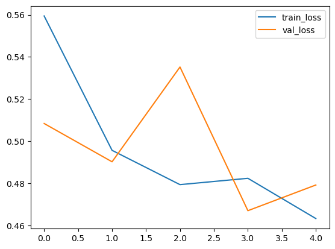

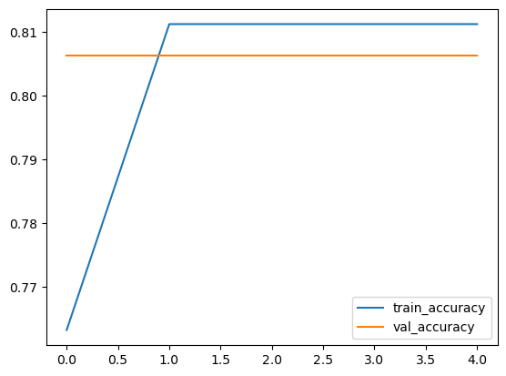

```python
# Plot training history
import matplotlib.pyplot as plt

plt.plot(history.history['loss'], label='train_loss')
plt.plot(history.history['val_loss'], label='val_loss')
plt.legend()
plt.show()

plt.plot(history.history['accuracy'], label='train_accuracy')
plt.plot(history.history['val_accuracy'], label='val_accuracy')
plt.legend()
plt.show()
```

### Step 6: Evaluate the Model

```python
loss, accuracy = model.evaluate(X_test, y_test)
print(f'Test loss: {loss}')
print(f'Test accuracy: {accuracy}')
```

```
1/1 ━━━━━━━━━━━━━━━━━━━━ 3s 3s/step - accuracy: 0.8063 - loss: 0.4792
Test loss: 0.47919750213623047
Test accuracy: 0.8062703609466553
```

### Conclusion:

**Further Training:** To improve the model’s performance, we can continue training for more epochs, fine-tune hyperparameters, or use data augmentation techniques to enhance the dataset.

## Alternate method

### Use of pre-trained Unet segmentation model using the library

```python
# pip install segmentation-models
```

```python
# pip install -U segmentation-models
```

```python
# pip install -U efficientnet
```

```python
from tensorflow import keras
```

```
5. Develop a Semantic segmentation model using Unet architecture on the given dataset.
Dataset contains the images and the corresponding masks. Find the dataset under the folder “Unet_Dataset”.

Note that the masks are binary. Define the architecture accordingly.
Students can make use of pre-trained Unet segmentation model using the library
import segmentation_models as sm
```

**Hints**

1. Load all the images in one array of size 150x128x128x3 Where 150 is total number of trained images 128x128x3 is each image size
2. Load all the masks in one array of size 150x128x128x1
3. Scale both the above two arrays
4. Split the data into train and test
5. Define the pre-trained segmentation model
6. Compile with appropriate loss and metric and fit the data into it.

Run the model for minimum 5 epochs and present your result. The solution will be evaluated based on approach only as it take lot of epochs to produce good result.

### Step 1: Load the Dataset

```python
import os
import numpy as np
import cv2

# Paths to the dataset
image_dir = "C:/Users/DELL/Desktop/Unet_Dataset/images"
mask_dir = "C:/Users/DELL/Desktop/Unet_Dataset/MASKS_BW"

# Initialize arrays
images = []
masks = []

# Load images
for img_name in sorted(os.listdir(image_dir)):
    img_path = os.path.join(image_dir, img_name)
    img = cv2.imread(img_path)
    img = cv2.resize(img, (128, 128))
    images.append(img)

# Load masks
for mask_name in sorted(os.listdir(mask_dir)):
    mask_path = os.path.join(mask_dir, mask_name)
    mask = cv2.imread(mask_path, cv2.IMREAD_GRAYSCALE)
    mask = cv2.resize(mask, (128, 128))
    masks.append(mask)

# Convert lists to numpy arrays
images = np.array(images)
masks = np.array(masks)

# Reshape masks to add channel dimension
masks = np.expand_dims(masks, axis=-1)

print(f'Images shape: {images.shape}')
print(f'Masks shape: {masks.shape}')
```

```
Images shape: (150, 128, 128, 3)
Masks shape: (150, 128, 128, 1)
```

### Step 2: Scale the Arrays

```python
images = images / 255.0
masks = masks / 255.0
```

### Step 3: Split the Data into Train and Test Sets

```python
from sklearn.model_selection import train_test_split

X_train, X_test, y_train, y_test = train_test_split(images, masks, test_size=0.2, random_state=42)

print(f'Training set shape: {X_train.shape}, {y_train.shape}')
print(f'Test set shape: {X_test.shape}, {y_test.shape}')
```

```
Training set shape: (120, 128, 128, 3), (120, 128, 128, 1)
Test set shape: (30, 128, 128, 3), (30, 128, 128, 1)
```

### Step 4: Define the Pre-trained Segmentation Model

Use the segmentation_models library to load a pre-trained U-Net model.

```python
import segmentation_models as sm
from tensorflow.keras.optimizers import Adam

# Define the model
BACKBONE = 'resnet34'
preprocess_input = sm.get_preprocessing(BACKBONE)

# Preprocess input
X_train = preprocess_input(X_train)
X_test = preprocess_input(X_test)

# Define the model
model = sm.Unet(BACKBONE, input_shape=(128, 128, 3), classes=1, activation='sigmoid')

# Compile the model
model.compile(optimizer=Adam(learning_rate=0.001), loss='binary_crossentropy', metrics=['accuracy'])

model.summary()
```

```
Segmentation Models: using `keras` framework.
```

```
Model: "functional_2"
```

```
┏━━━━━━━━━━━━━━━━━━━━━┳━━━━━━━━━━━━━━━━━━━┳━━━━━━━━━━━━┳━━━━━━━━━━━━━━━━━━━┓
┃ Layer (type)        ┃ Output Shape      ┃    Param # ┃ Connected to      ┃
┡━━━━━━━━━━━━━━━━━━━━━╇━━━━━━━━━━━━━━━━━━━╇━━━━━━━━━━━━╇━━━━━━━━━━━━━━━━━━━┩
│ data (InputLayer)   │ (None, 128, 128,  │          0 │ -                 │
│                     │ 3)                │            │                   │
├─────────────────────┼───────────────────┼────────────┼───────────────────┤
│ bn_data             │ (None, 128, 128,  │          9 │ data[0][0]        │
│ (BatchNormalizatio… │ 3)                │            │                   │
├─────────────────────┼───────────────────┼────────────┼───────────────────┤
│ zero_padding2d      │ (None, 134, 134,  │          0 │ bn_data[0][0]     │
│ (ZeroPadding2D)     │ 3)                │            │                   │
├─────────────────────┼───────────────────┼────────────┼───────────────────┤
│ conv0 (Conv2D)      │ (None, 64, 64,    │      9,408 │ zero_padding2d[0… │
│                     │ 64)               │            │                   │
├─────────────────────┼───────────────────┼────────────┼───────────────────┤
│ bn0                 │ (None, 64, 64,    │        256 │ conv0[0][0]       │
│ (BatchNormalizatio… │ 64)               │            │                   │
├─────────────────────┼───────────────────┼────────────┼───────────────────┤
│ relu0 (Activation)  │ (None, 64, 64,    │          0 │ bn0[0][0]         │
│                     │ 64)               │            │                   │
├─────────────────────┼───────────────────┼────────────┼───────────────────┤
│ zero_padding2d_1    │ (None, 66, 66,    │          0 │ relu0[0][0]       │
│ (ZeroPadding2D)     │ 64)               │            │                   │
├─────────────────────┼───────────────────┼────────────┼───────────────────┤
│ pooling0            │ (None, 32, 32,    │          0 │ zero_padding2d_1… │
│ (MaxPooling2D)      │ 64)               │            │                   │
├─────────────────────┼───────────────────┼────────────┼───────────────────┤
│ stage1_unit1_bn1    │ (None, 32, 32,    │        256 │ pooling0[0][0]    │
│ (BatchNormalizatio… │ 64)               │            │                   │
├─────────────────────┼───────────────────┼────────────┼───────────────────┤
│ stage1_unit1_relu1  │ (None, 32, 32,    │          0 │ stage1_unit1_bn1… │
│ (Activation)        │ 64)               │            │                   │
├─────────────────────┼───────────────────┼────────────┼───────────────────┤
│ zero_padding2d_2    │ (None, 34, 34,    │          0 │ stage1_unit1_rel… │
│ (ZeroPadding2D)     │ 64)               │            │                   │
├─────────────────────┼───────────────────┼────────────┼───────────────────┤
│ stage1_unit1_conv1  │ (None, 32, 32,    │     36,864 │ zero_padding2d_2… │
│ (Conv2D)            │ 64)               │            │                   │
├─────────────────────┼───────────────────┼────────────┼───────────────────┤
│ stage1_unit1_bn2    │ (None, 32, 32,    │        256 │ stage1_unit1_con… │
```

[output cut: 544 more lines]

```
│ decoder_stage4b_co… │ (None, 128, 128,  │      2,304 │ decoder_stage4a_… │
│ (Conv2D)            │ 16)               │            │                   │
├─────────────────────┼───────────────────┼────────────┼───────────────────┤
│ decoder_stage4b_bn  │ (None, 128, 128,  │         64 │ decoder_stage4b_… │
│ (BatchNormalizatio… │ 16)               │            │                   │
├─────────────────────┼───────────────────┼────────────┼───────────────────┤
│ decoder_stage4b_re… │ (None, 128, 128,  │          0 │ decoder_stage4b_… │
│ (Activation)        │ 16)               │            │                   │
├─────────────────────┼───────────────────┼────────────┼───────────────────┤
│ final_conv (Conv2D) │ (None, 128, 128,  │        145 │ decoder_stage4b_… │
│                     │ 1)                │            │                   │
├─────────────────────┼───────────────────┼────────────┼───────────────────┤
│ sigmoid             │ (None, 128, 128,  │          0 │ final_conv[0][0]  │
│ (Activation)        │ 1)                │            │                   │
└─────────────────────┴───────────────────┴────────────┴───────────────────┘
```

```
 Total params: 24,456,154 (93.29 MB)
```

```
 Trainable params: 24,438,804 (93.23 MB)
```

```
 Non-trainable params: 17,350 (67.77 KB)
```

### Step 5: Train the Model

```python
history = model.fit(X_train, y_train, epochs=5, batch_size=16, validation_data=(X_test, y_test))
```

```
8/8 ━━━━━━━━━━━━━━━━━━━━ 52s 2s/step - accuracy: 0.7957 - loss: 0.4786 - val_accuracy: 0.4811 - val_loss: 0.7418
8/8 ━━━━━━━━━━━━━━━━━━━━ 14s 2s/step - accuracy: 0.8824 - loss: 0.3024 - val_accuracy: 0.1800 - val_loss: 5.6785
8/8 ━━━━━━━━━━━━━━━━━━━━ 14s 2s/step - accuracy: 0.8958 - loss: 0.2447 - val_accuracy: 0.1835 - val_loss: 2.8554
8/8 ━━━━━━━━━━━━━━━━━━━━ 15s 2s/step - accuracy: 0.9017 - loss: 0.2130 - val_accuracy: 0.1806 - val_loss: 9.3461
8/8 ━━━━━━━━━━━━━━━━━━━━ 14s 2s/step - accuracy: 0.9327 - loss: 0.1587 - val_accuracy: 0.1699 - val_loss: 93.1350
```

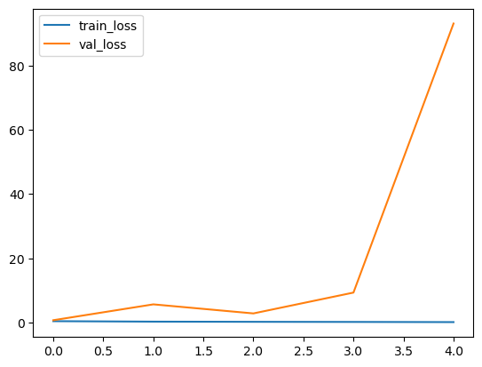

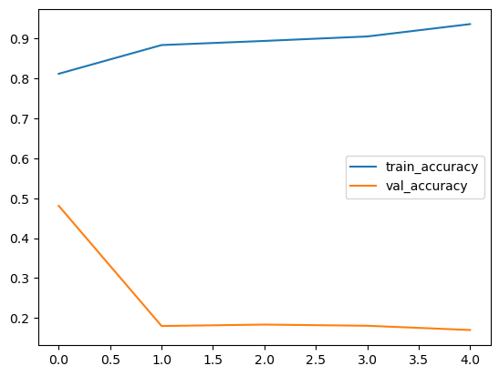

```python
# Plot training history
import matplotlib.pyplot as plt

plt.plot(history.history['loss'], label='train_loss')
plt.plot(history.history['val_loss'], label='val_loss')
plt.legend()
plt.show()

plt.plot(history.history['accuracy'], label='train_accuracy')
plt.plot(history.history['val_accuracy'], label='val_accuracy')
plt.legend()
plt.show()
```

### Step 8: Evaluate the Model

```python
loss, accuracy = model.evaluate(X_test, y_test)
print(f'Test loss: {loss}')
print(f'Test accuracy: {accuracy}')
```

```
1/1 ━━━━━━━━━━━━━━━━━━━━ 1s 855ms/step - accuracy: 0.1699 - loss: 93.1350
Test loss: 93.13497924804688
Test accuracy: 0.16991780698299408
```

**Inference:** It seems like our model is experiencing significant overfitting. The training accuracy is very high at 93.27% with a low loss of 0.1587, but the validation accuracy is very low at 16.99% with a high loss of 93.1350. This discrepancy indicates that our model is not generalizing well to the validation data.